# Energetics of Reproduction in *Sternotherus odoratus*

Lyranda Thiem

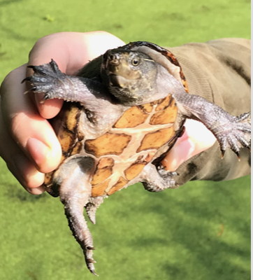

## Introduction

The life history theory suggests a form of tradeoff in the allocation of energy into present and future offspring, which is determined by reproductive effort, mode of reproduction, and reproductive frequency(Shine 1980).Many reptiles lack parental care after oviposition. Turtles are of no exception; instead turtles invest all of their reproductive effort into their offspring prior to oviposition.Reproductive effort is directed towards mating, vitellogensis (producing a yolk sac), develeping the embryo, creating a shell layer, and retaining eggs within the oviduct until the environment is optimal for nesting.All known turtles today have the ability to retain eggs for an extended period of time.Some turtles such as the chicken turtle are capable of retaining eggs for half a year, while other turtles like snapping turtles are capable of retaining their eggs for two weeks once eggs have been fully shelled(Kuchling 1999). The primary goal of this study is to assess the energetic tradeoffs of egg retention as a form of parental care, and if so suggest how this would be a beneficial reproductive strategy if energy investments are low. To address this question we examined the metabolic rates of gravid females pre and post oviposition, males, and non-gravid metabolic rates using open and closed circuit respirometry

**Hypothesis**: Oviductal egg retention is a beneficial reproductive strategt because it permits flexibility in the timing of oviposition, but has minimal energetic costs.

*Objective 1*:Determine the energetic costs of retaining eggs for gravid females.For gravid females, retaining viable eggs (within the oviduct) is a beneficial strategy if the energetic cost is low. If this is true, we predict the duration of egg retention will be low compared to the energy investment for non-gravid females and males. Thereby egg retention should be a beneficial reproductive strategy

*Objective 2*: Determine the reproductive effort of gravid females throughout their oviductal egg retention period. We would predict that females will have increased metabolic rates early on in reproduction due to vitellogenesis (yolk sac formation). Their metabolic rates would then decreased as they approached oviposition.

*Objective 3*:Determine if metabolic rates differ between females gravid metabolic rates and their non-gravid metabolic rate.If the cost of retaining eggs in the oviduct is low then we would predict there would be no difference in gravid and non-gravid metabolic rates.d

## Methods

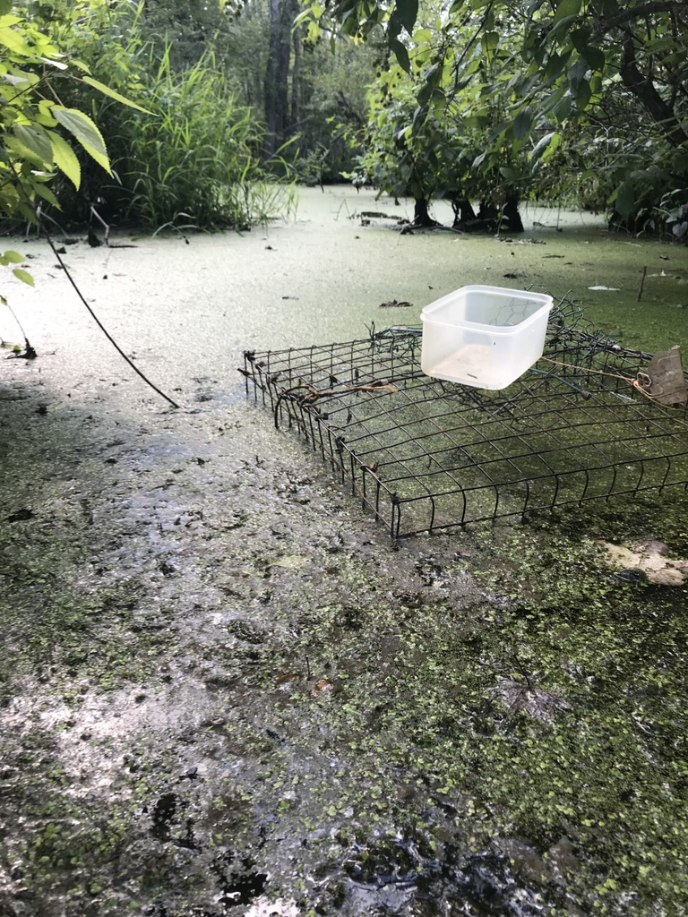

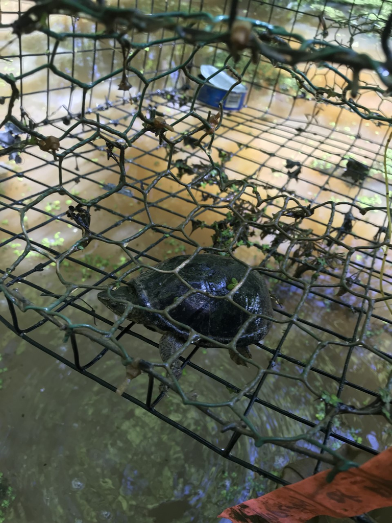

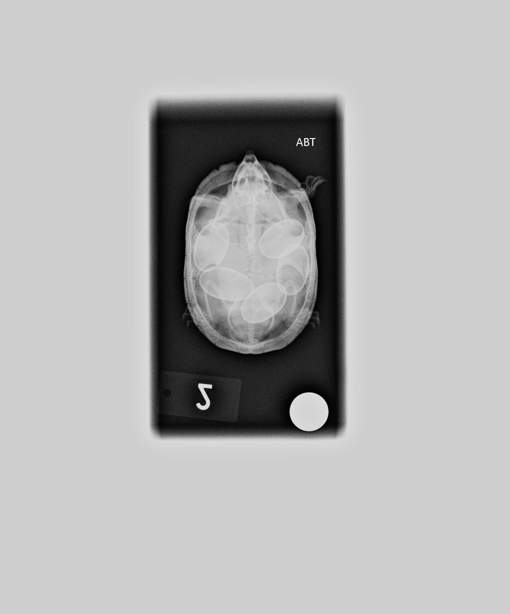

-Turtles were collected using Jones Traps

-Turtles were marked, weighed, and length of carapace and plastron was measured

-Females were x-rayed to determine whether they were gravid

-Turtles housed for three days prior to sampling and allowed to become digestively post absorptive

-Open-circuit respirometry was used to measure CO2 production for 48 hrs.

-Closed-circuit respirometry was used to measures O2 consumption 24 hrs after oviposition

-Conversion factors were used to convert metabolic measurements to joules/hr

-Metabolic rates were adjusted for mass and an ANCOVA with a pairwise analysis was run

-A Mixed model was run to determine signficant effects on female metabolic rate

-Repeated measures ANOVA with a post hoc was run to determine if gravid metabolic rates over time were signficant

### Site Description

Musk Turtles (Sternotherus odoratus) were captured from backwater sloughs along the Cumberland River, Cheatham County, Tennessee using Jones traps (Chandler et al. 2017).Traps were baited with canned tuna or sardines and placed in water deep enough to be mostly submerged, which allowed them to be left overnight and be checked the following day. Traps were left in the same location for a week prior to being moved. Traps were placed in murky/muddy water with duckweed covering.Trapping was conducted during the reproductive season from mid-May to September (Mitchell 1985, Ernst 1986, Ford and Moll 2004).

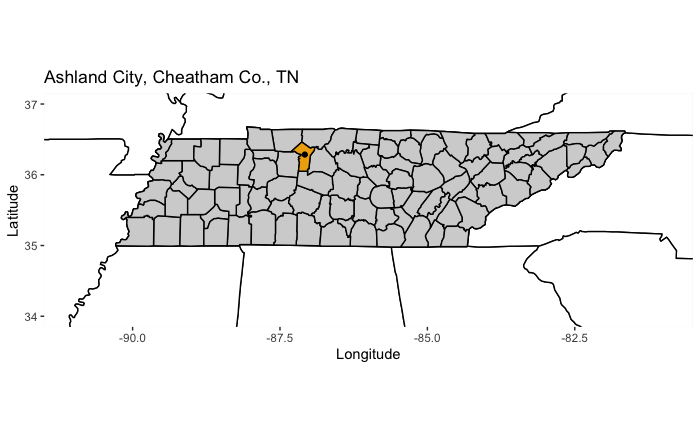

```
Assuming "longitude" and "latitude" are longitude and latitude, respectively
```

[interactive chart not shown]

## Results

**Adjusting for Egg Metabolism**

Before we can run any tests we need to calculate energy produced during the respirometry run we need to convert our mL CO2/hr into joules/hr using conversion factors. The conversion factors were taken from Gessaman and Nagey 1988 and Reid et al 2009.

*Egg energy expenditure:* Conversion factor from Reid et al. 2009 VO2 converstion factor= 20.1 J/ml O2

After converting metabolic rates from mLCO2/h to joules/h we need to them subtract the metabolic rates of the whole clutch from the respected gravid female because we only want to examine the gravid females metabolic rate.

**Data Description**

Below is a description of all the factor variables included within my data set.

**Group**: Gravid Females, Males, Non-Gravid Females

**mlCO2/hr turtles**: measured metabolic rates

**Turtle_Mass**: Individual turtle mass to the nearest gram

**mlO2/min eggs**: measured metabolic rates for whole clutch of eggs

**Whole clutch mass**: reported weigths(g) of the entire clutch for each gravid female

**mlO2/hr eggs**: measured metabolic rates for whole clutch of eggs

**Joules/hr turtles**: calculated joules per hour used my indivudal turtles using the conversion factor

**Joules/hr whole clutch**: calculated joules per hour used by the whole clutch from each gravid female

**adj_energy_joules_turtles**: subtracting the joules/hr for the clutch from each of the gravid females

Table 6. A knitr kable Gravid SMR Musk Turtle data.

| Turtle_ID | Group | mL_CO2_hr_turtles | Turtle_Mass | ml_O2_min_eggs | whole_clutch_mass | ml_O2_hr_eggs | Joules_hr_turtles | Joules_hr_whole_clutch | adj_energy_Joules_turtles | adj_mass_turtles |
| --- | --- | --- | --- | --- | --- | --- | --- | --- | --- | --- |
| ABL | Gravid Female | 4.708550 | 154 | 0.0002582 | 16.9 | 0.0154932 | 114.51194 | 0.3114133 | 114.20052 | 137.1 |
| ACI | Gravid Female | 3.683805 | 111 | 0.0001496 | 14.3 | 0.0089736 | 89.59014 | 0.1803694 | 89.40977 | 96.7 |
| ABU | Gravid Female | 5.171930 | 146 | 0.0002176 | 18.0 | 0.0130554 | 125.78134 | 0.2624135 | 125.51892 | 128.0 |
| ABT | Gravid Female | 5.103395 | 145 | 0.0003070 | 12.4 | 0.0184200 | 124.11457 | 0.3702420 | 123.74432 | 132.6 |
| ACT | Gravid Female | 4.757630 | 124 | 0.0002781 | 14.0 | 0.0166836 | 115.70556 | 0.3353404 | 115.37022 | 110.0 |
| ACO | Gravid Female | 5.281002 | 196 | 0.0003208 | 19.8 | 0.0192456 | 128.43396 | 0.3868366 | 128.04712 | 176.2 |
| AHT | Gravid Female | 3.886640 | 139 | 0.0003126 | 17.0 | 0.0187584 | 94.52308 | 0.3770438 | 94.14604 | 122.0 |
| AHM | Gravid Female | 2.935713 | 100 | 0.0001420 | 11.1 | 0.0085224 | 71.39655 | 0.1713002 | 71.22525 | 88.9 |
| AHL | Gravid Female | 4.439160 | 149 | 0.0003954 | 15.1 | 0.0237246 | 107.96037 | 0.4768645 | 107.48351 | 133.9 |
| AH | Gravid Female | 4.672387 | 126 | 0.0002273 | 11.0 | 0.0136392 | 113.63244 | 0.2741479 | 113.35830 | 115.0 |

### Group Metabolic Rates

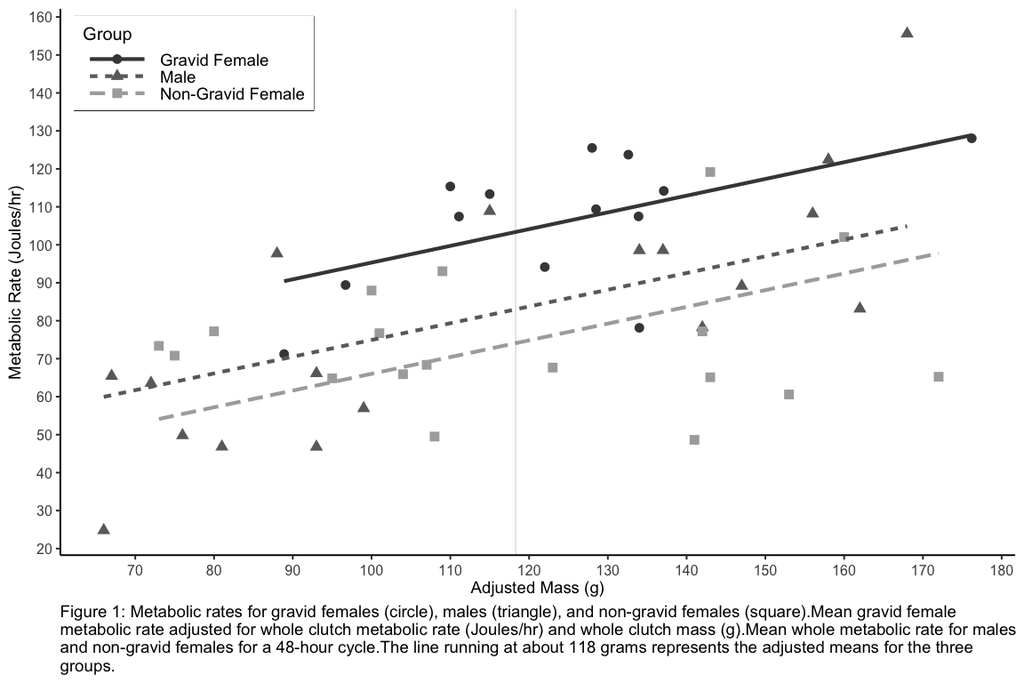

```r
gravid_plot+ guides(fill = guide_legend(keywidth = 1, keyheight = 1, cex=0.75),
    linetype=guide_legend(keywidth = 4, keyheight = 1),
    colour=guide_legend(keywidth = 4, keyheight = 1))+
   theme(legend.position = c(.14,.90),legend.box.background = element_rect(colour = "black"),
         axis.text.x = element_text(vjust=0.5, size = 12),
         axis.text.y = element_text(vjust = 0.5, size=12),
         axis.title.x = element_text(size=14),
         axis.title.y= element_text(size=14),
         legend.text = element_text(color = "black", size = 14))+
  labs(caption = "Figure 1: Metabolic rates for gravid females (circle), males (triangle), and non-gravid females (square).Mean gravid female
metabolic rate adjusted for whole clutch metabolic rate (Joules/hr) and whole clutch mass (g).Mean whole metabolic rate for males
and non-gravid females for a 48-hour cycle.The line running at about 118 grams represents the adjusted means for the three
groups.")+
  theme(plot.caption = element_text(hjust = 0, size=14))
```

All turtles have a positive correlation in metabolic rates (joules/hr) while accounting for the adjusted turtle mass (subtracting the gravid female’s clutch mass from her mass in order to get the actual mass of the female). From the graph it looks as though gravid females have a higher metabolic rate then do males and non-gravid females for the the reproductive season. We will run an ANCOVA with a pairwise test to determine if this is the case for these turtles.

Before running an ANCOVA and a pairwise test I ran the an autoplot to check for potential outliers. Here we see in the normal Q-Q plot that three values (16,15,36) could be potential outliers, however, they do not seem to deviate from the line too much so they may be okay.The first and third plot do not show any signficant pattern which is good.

### Checking Normality

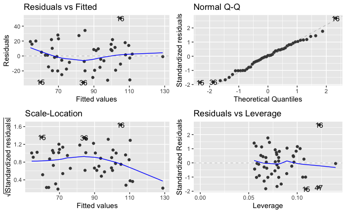

### ANCOVA/Adjusted Means

I ran an ANCOVA with adjusted means analysis in order to determine the average metabolic rates for each group while accounting for the covariate of body mass.

Table 1. A summary kable displaying ANOVA summary table.

|  | Df | Sum Sq | Mean Sq | F value | Pr(>F) |
| --- | --- | --- | --- | --- | --- |
| adj_mass_turtles | 1 | 9959.259 | 9959.2592 | 24.587475 | 1.06e-05 |
| Group | 2 | 6550.128 | 3275.0639 | 8.085496 | 1.00e-03 |
| Residuals | 45 | 18227.437 | 405.0542 | NA | NA |

The ANCOVA results support the linear plot above in that group (gravid female, male, non-gravid female) is signficant in determing metabolic rates of the indivdual turtle.The adjusted mass also was signficantly correlated with metabolic rates of the turtles (joules/hr) with a p-value< 0.05.

### Emmeans

In order to adjust for the difference in mass of the three groups of turtles we need to use the package library(emmeans) to run our model.

Table 2: Adjusted means for turtles accounting for mass of groups

| Adjusted Mass(g) | Group | Mean MR (joules/h) | SE | df |
| --- | --- | --- | --- | --- |
| 118 | Gravid Female | 103.4 | 5.61 | 45 |
| 118 | Male | 83.0 | 4.76 | 45 |
| 118 | Non-Gravid Female | 74.1 | 4.74 | 45 |

```r
formattable(pairs_table, align = c("l", rep("r", NCOL(adj_turtles_1) - 1)), caption= "Table 3: Pairwise analysis after adjusting for body mass of all individuals. ")
```

Table 3: Pairwise analysis after adjusting for body mass of all individuals.

| Contrast | Estimate | SE | t.ratio | p.value |
| --- | --- | --- | --- | --- |
| 118.306 Gravid Female- 118.306 Male | 20.38 | 7.39 | 2.76 | 0.022 |
| 118.306 Gravid Female- 118.306 Non-Gravid Female | 29.29 | 7.35 | 3.99 | 0.001 |
| 118.306 Male- 118.306 Non-Gravid Female | 8.91 | 6.72 | 1.33 | 0.388 |

After adjusting for the means of the metabolic rates we can now run a pairwise analysis to see if there were any differences among the group. Here we see that we get a signficant diffence between gravid females and males (p-value-0.022). A signficant difference is also seen between gravid females and non-gravid females (p-value=0.001). A nonsignficant difference is reported when looking at males and non-gravid females (p-value=0.388).

### Pre and Post Oviposition Metabolic Rate

```r
new_data<- egg_retention_period[ -c( 7,14, 15), ]
```

```r
time_plot_2<- ggplot(data = new_data, aes(x = Days_To_Oviposition, y = mL_CO2_hr)) +
  geom_point(color='black')+
  annotate(geom="text", x=6, y=8, label="Post-Oviposition",size = 5,
              color="black")+
   annotate(geom="text", x=-40, y=8, label="Pre-Oviposition",size = 5,
              color="black")+
  geom_vline(xintercept = 0, col="black", alpha=0.7, linetype="dashed")+
  xlab("Days Before Oviposition")+
  ylab("Metabolic Rates (mLCO2/hr)")+
  theme_classic()+
   geom_smooth(aes(group=new_data$Status), method = "lm", col="black")# to make the best fit line
```

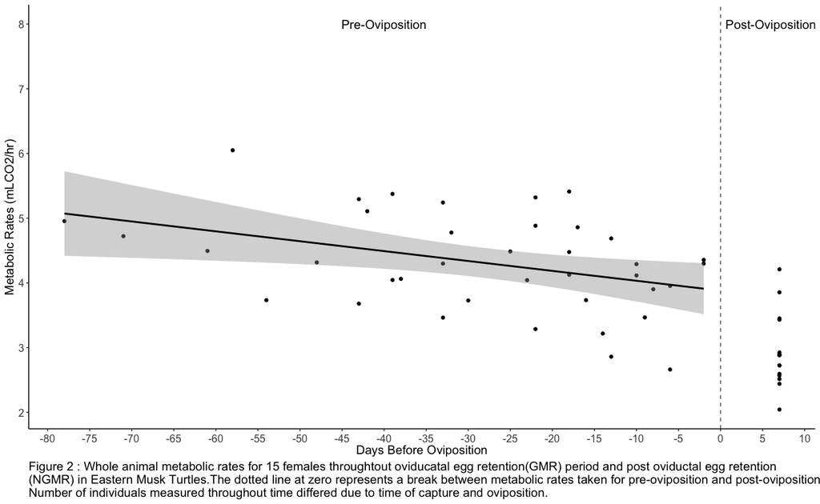

```r
time_plot_2+ scale_x_continuous(breaks = c(-85,-80,-75, -70,-65, -60,-55,-50,-45,-40,-35,-30,-25,-20,-15,-10,-5, 0,5, 10))+ scale_y_continuous(breaks=c(0,1,2,3,4,5,6,7,8))+
  labs(caption = "Figure 2 : Whole animal metabolic rates for 15 females throughtout oviducatal egg retention(GMR) period and post oviductal egg retention
(NGMR) in Eastern Musk Turtles.The dotted line at zero represents a break between metabolic rates taken for pre-oviposition and post-oviposition.
Number of individuals measured throughout time differed due to time of capture and oviposition.")+
  theme(plot.caption = element_text(hjust = 0, lineheight = 0.9, size=14),
       axis.text.x = element_text(vjust=0.5, size = 12),
         axis.text.y = element_text(vjust = 0.5, size=12),
         axis.title.x = element_text(size=14),
         axis.title.y= element_text(size=14))
```

### GLM with Non-normal Data

I ran a poisson log link glm because I have non-normal data where individuals were measured multiple times throughout their gravidity stage. We want to look at the days prior to oviposition, so we need to exclude any days after zero

```r
pois1 <- glm(mL_CO2_hr~Days_To_Oviposition+Turtle_ID, family= poisson(link=log), data= excluding_post_gravid)
```

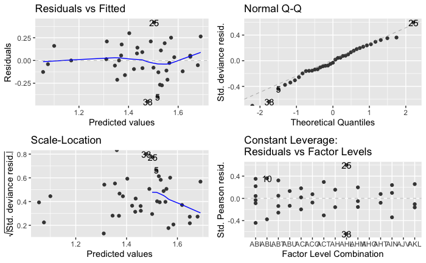

```r
autoplot(pois1)
```

```r
excluding_post_gravid$Days_To_Oviposition <- factor(excluding_post_gravid$Days_To_Oviposition)
my.mod<- glm(mL_CO2_hr~Days_To_Oviposition+Turtle_ID, data=excluding_post_gravid,  poisson(link=log))

summary(my.mod)
```

```
Call:
glm(formula = mL_CO2_hr ~ Days_To_Oviposition + Turtle_ID, family = poisson(link = log),
    data = excluding_post_gravid)

Deviance Residuals:
      1        2        3        4        5        6        7        8        9       10       11       12
 0.0000   0.0000   0.0000   0.0000   0.0000   0.0000   0.0000   0.0000   0.0000   0.0000   0.0000   0.0000
     13       14       15       16       17       18       19       20       21       22       23       24
-0.0547   0.0854  -0.0432   0.0000   0.0000   0.0000   0.0000  -0.0827   0.0573   0.0411  -0.0482   0.0510
     25       26       27       28       29       30       31       32       33       34       35       36
 0.0000   0.0000   0.0000   0.0000   0.0000   0.0000   0.0000   0.0000   0.0000   0.0000   0.0522  -0.0622
     37       38
 0.0000   0.0000

Coefficients: (4 not defined because of singularities)
                       Estimate Std. Error z value Pr(>|z|)
(Intercept)             1.60032    0.44926    3.56  0.00037 ***
Days_To_Oviposition-71 -0.04797    0.64310   -0.07  0.94054
Days_To_Oviposition-61  0.30953    1.51788    0.20  0.83841
Days_To_Oviposition-58  0.24281    1.33642    0.18  0.85583
Days_To_Oviposition-54 -0.28308    0.68535   -0.41  0.67958
Days_To_Oviposition-48 -0.13776    0.65839   -0.21  0.83426
Days_To_Oviposition-43  0.10940    1.34522    0.08  0.93518
Days_To_Oviposition-42  0.01732    0.92729    0.02  0.98510
Days_To_Oviposition-39 -0.20283    0.67011   -0.30  0.76213
Days_To_Oviposition-38 -0.21155    0.95405   -0.22  0.82452
Days_To_Oviposition-33 -0.03647    1.06782   -0.03  0.97276
Days_To_Oviposition-32  0.00685    1.35278    0.01  0.99596
Days_To_Oviposition-30 -0.28437    0.68561   -0.41  0.67830
Days_To_Oviposition-25 -0.09950    0.65175   -0.15  0.87866
Days_To_Oviposition-23 -0.48770    0.93941   -0.52  0.60365
Days_To_Oviposition-22  0.05165    1.01327    0.05  0.95935
Days_To_Oviposition-18  0.08394    1.10939    0.08  0.93969
Days_To_Oviposition-17 -0.01939    0.63845   -0.03  0.97577
Days_To_Oviposition-16  0.12401    1.53274    0.08  0.93552
Days_To_Oviposition-14 -0.43172    0.71599   -0.60  0.54652
Days_To_Oviposition-13 -0.05561    0.64437   -0.09  0.93122
Days_To_Oviposition-10 -0.10085    1.17799   -0.09  0.93177
Days_To_Oviposition-9  -0.36130    1.30537   -0.28  0.78195
Days_To_Oviposition-8  -0.23877    0.67683   -0.35  0.72426
```

[output cut: 11 more lines]

```
Turtle_IDAHO                 NA         NA      NA       NA
Turtle_IDAHT                 NA         NA      NA       NA
Turtle_IDAIN            0.01308    0.67988    0.02  0.98465
Turtle_IDAJV                 NA         NA      NA       NA
Turtle_IDAKL           -0.08473    0.97100   -0.09  0.93046
---
Signif. codes:  0 ‘***’ 0.001 ‘**’ 0.01 ‘*’ 0.05 ‘.’ 0.1 ‘ ’ 1

(Dispersion parameter for poisson family taken to be 1)

    Null deviance: 4.944550  on 37  degrees of freedom
Residual deviance: 0.035507  on  2  degrees of freedom
AIC: Inf

Number of Fisher Scoring iterations: 3
```

Days leading up to oviposition were non-signficant so we do not need to run a post hoc test or paired t-test to determine if there was a signficant between days.

```r
pois1 <- glm(mL_CO2_hr~Status, family= poisson(link=log), data= new_data)
summary(pois1)
```

```
Call:
glm(formula = mL_CO2_hr ~ Status, family = poisson(link = log),
    data = new_data)

Deviance Residuals:
   Min      1Q  Median      3Q     Max
-0.855  -0.223  -0.027   0.259   0.790

Coefficients:
                      Estimate Std. Error z value Pr(>|z|)
(Intercept)              1.079      0.151    7.17  7.4e-13 ***
StatusPre-Oviposition    0.381      0.170    2.25    0.024 *
---
Signif. codes:  0 ‘***’ 0.001 ‘**’ 0.01 ‘*’ 0.05 ‘.’ 0.1 ‘ ’ 1

(Dispersion parameter for poisson family taken to be 1)

    Null deviance: 11.8646  on 52  degrees of freedom
Residual deviance:  6.4366  on 51  degrees of freedom
AIC: Inf

Number of Fisher Scoring iterations: 4
```

```r
time_plot_2<- ggplot(data = new_data, aes(x = Days_To_Oviposition, y = mL_CO2_hr)) +
  geom_point(color='black')+
  annotate(geom="text", x=6, y=8, label="Post-Oviposition",size = 5,
              color="black")+
   annotate(geom="text", x=-40, y=8, label="Pre-Oviposition",size = 5,
              color="black")+
  geom_vline(xintercept = 0, col="black", alpha=0.7, linetype="dashed")+
  xlab("Days Before Oviposition")+
  ylab("Metabolic Rates (mLCO2/hr)")+
  theme_classic()+
   geom_smooth(aes(group=new_data$Status), method.args=list(family="poisson"(link="log"), col="black"))# to make the best fit line
```

```r
time_plot_3+ scale_x_continuous(breaks = c(-85,-80,-75, -70,-65, -60,-55,-50,-45,-40,-35,-30,-25,-20,-15,-10,-5, 0,5, 10))+ scale_y_continuous(breaks=c(0,1,2,3,4,5,6,7,8))+
  labs(caption = "Figure 2 : Whole animal metabolic rates for 15 females throughtout oviducatal egg retention(GMR) period and post oviductal egg retention
(NGMR) in Eastern Musk Turtles.The dotted line at zero represents a break between metabolic rates taken for pre-oviposition and post-oviposition.
Number of individuals measured throughout time differed due to time of capture and oviposition.")+
  theme(plot.caption = element_text(hjust = 0, lineheight = 0.9, size=14),
       axis.text.x = element_text(vjust=0.5, size = 12),
         axis.text.y = element_text(vjust = 0.5, size=12),
         axis.title.x = element_text(size=14),
         axis.title.y= element_text(size=14))
```

[output not shown]